# slide_deck_FordGoBike-Copy1 slides

## Data Analysis and Visualization Report: Ford GoBike System Trends and Types April, 2019

#### by Daniel Muthama

## Investigation Overview

In this investigation, I will to look at the bike ride trends and biker type of the bay Area bike share system. The main focus was on biking duration, the time (weekday, hour), and the bike types.

## Dataset Overview

This document explores the Ford GoBike's trip data for public containing bike rides from April FY2019. The attributes included the trip start/end time, as well as additional measurements such as user type, gender, and age. 16K data points were removed from the analysis due to missing values in some fields, data inconsistent, or outliner issues.

## Bike Ride Duration Time Visualization:

### The original duration data has right skew issue - bike durations range from less than 1 minute to 1400+ minutes with median at around 9 min and mean at around 12 min.

### We have to do some data transformation to make data visualization and data interpretation easiler. Below are the plots before/after data transformation.

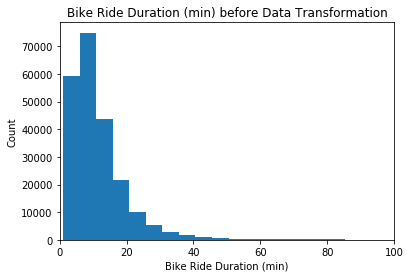

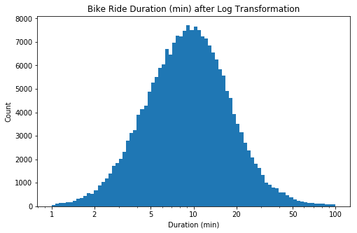

## Daily/Weekly Bike Ride Trends and Biker Type Visualization:

#### Features investigated include the following: Start Time Hour, Start Time DayofWeek, Member Gender, and User Type.

#### Observations from below plots:

> - Tuesday, 5:00 PM has the highest biker counts across 7 days, 24 hours.
> - 5:00 PM has the most male bikers compared to other hours. 8:00 AM and 5:00 PM have more female bikers compared to other hours.
> - 5:00 PM has the most 'Subscriber' bikers compared to other hours. It also has the most 'Customer' bikers compared to other hours.
> - Tuesday has the most male bikers compared to other days. It also has the most female bikers compared to other days.
> - Tuesday has the most 'Subscriber' bikers compared to other days. Saturday has the most 'Customer' bikers compared to other days.
> - Most 'Subscriber' are male. Most 'Customer' bikers are also male.

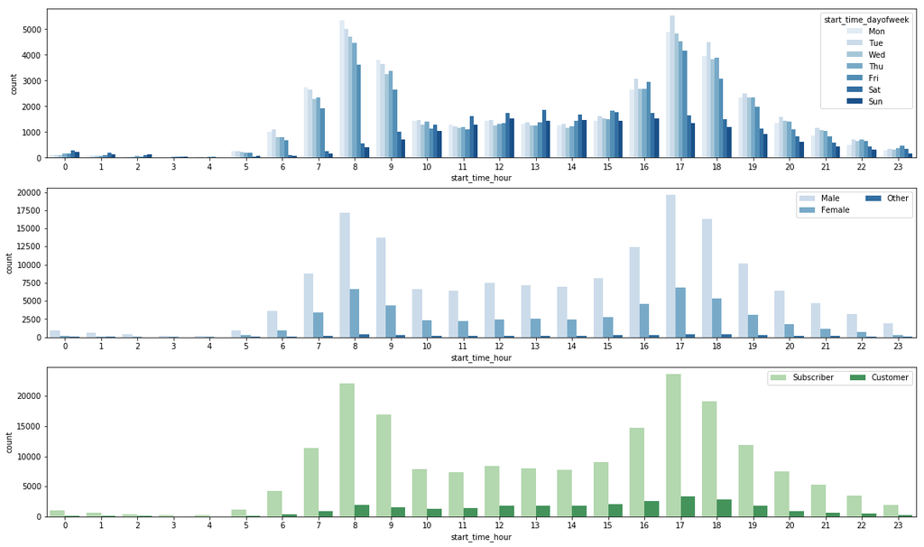

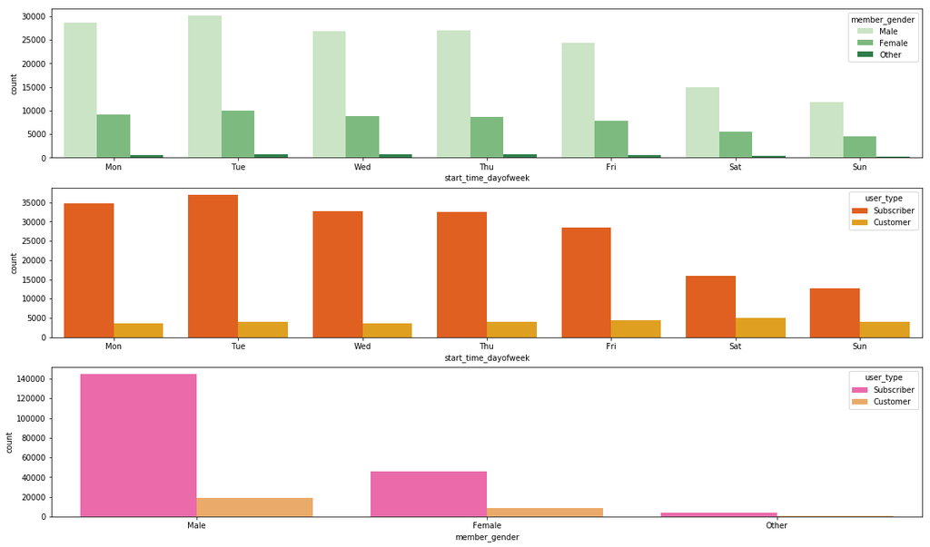

## Bike Ride Durations for Different Age Group Across DayofWeek and Hour Visulization:

**Observations:**

> - By looking at the errorbars in both pointplots below, we can tell that there are more younger bikers (age < 40) across 7 days and 24 hours.
> - Bikers on Saturday and Sunday bike longer compared to bikers on other days.

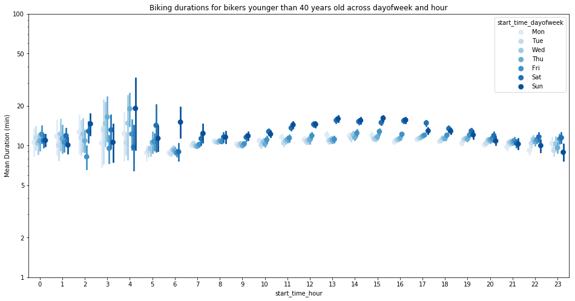

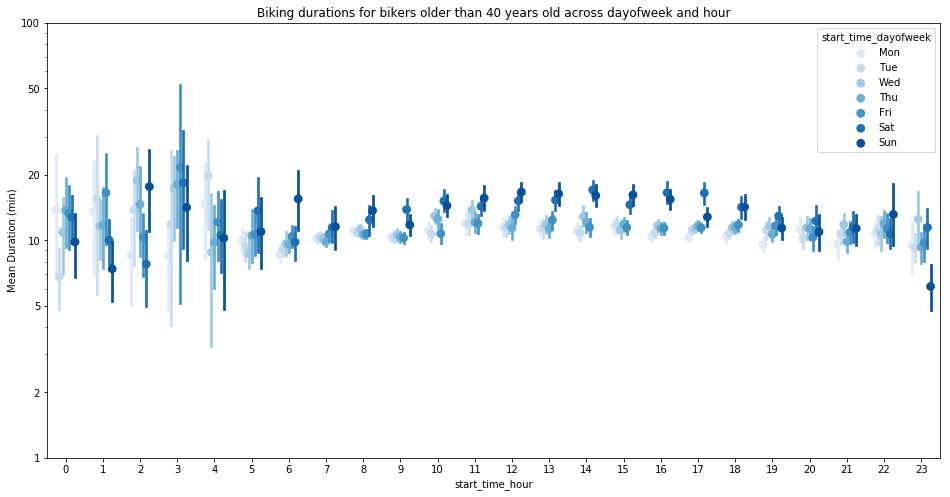